# R Notebook

# Load required libraries

```r
library("hdxstats")
library("dplyr")
library("ggplot2")
library("RColorBrewer")
library("tidyr")
library("pheatmap")
library("scales")
library("viridis")
library("patchwork")
library("Biostrings")
library("xfun")
library("tidyverse")
```

```r
source("R/test_script_app2.R")
```

# Parsing Raw Data

Parse input raw data and output `QFeatures` object instance given a CSV file path for different test cases.

```r
# First test case
csv_filepath <- "/homes/sanjuan/R/x86_64-pc-linux-gnu-library/4.1/hdxstats/extdata/MBP.csv"

# CASE 1: Parse data, given input data file path + parameter file
hdx_data <- extract_hdx_data(csv_filepath, parameter_file = "vignettes/data/myparameters.hdxp")

# CASE 2: Parse data, given input data file path + list of parameters
data <- read_csv(csv_filepath)
myparameters <- make_parameter_file(data)
hdx_data <- extract_hdx_data(csv_filepath, parameters = myparameters)

# CASE 3: Parse data, given input data file path. Work out parameters for pre-processing using interactive mode
```

```r
hdx_data <- extract_hdx_data(csv_filepath, parameter_file = "vignettes/data/myparameters.hdxp")
```

# Data Analysis of Deuterium Uptake Kinetics

## TEST 1:

### Perform Data Analysis: Plain fitting

- Deuterium-update fitting for all peptides
- Plain fitting - not comparing against a reference state or condition

```r
# INPUT
data_selection <- hdx_data[,1:24]
all_peptides <- rownames(data_selection)[[1]]
starting_parameters <- list(a = NULL, b = 0.001,  d = NULL, p = 1)
# OUTPUT
results <- analyse_kinetics(data = data_selection,
                            method = "fit",
                            peptide_selection = all_peptides,
                            start = starting_parameters)
```

```r
results$method
```

### Visualise Output from Data Analysis

View fitting curves of Deu-uptake kinetics for all available conditions associated to selected peptides

```r
graphics_kinetics <- visualise_hdx_data(results, type="kinetics")
graphics_kinetics[[1]] | graphics_kinetics[[2]] | graphics_kinetics[[3]]
```

View forest plots showing the difference between uptake measurements between conditions, plus the dispersion between their respective fitting model parameters

```r
graphics_forest <- visualise_hdx_data(results, type="forest")
graphics_forest[[1]] | graphics_forest[[2]] | graphics_forest[[3]]
```

Combine graphical outputs in a single canvas

```r
graphics_forest[[1]] | graphics_kinetic[[1]]
```

Display numerical values as a table

```r
graphics_forest[[1]]$data
```

### Perform Data Analysis: Differential fitting

- Deuterium-update fitting for data selection
- Differential fitting - with respect to a *single reference* peptide

```r
# INPUT
data_selection <- hdx_data[,1:100]
all_peptides <- rownames(data_selection)[[1]] # get all peptides
starting_parameters <- list(a = NULL, b = 0.0001,  d = NULL, p = 1)

# OUTPUT
results <- analyse_kinetics(data = data_selection,
                            method = "dfit",
                            peptide_selection = all_peptides[37],
                            start = starting_parameters)
```

```r
graphics_kinetics <- visualise_hdx_data(results, type="kinetics")
```

```r
graphics_kinetics
```

## TEST CASE 2

Single-domain antibody (sdAb) binding assays to HOIP.

```r
csv_filepath <- "/home/sanjuan/R/x86_64-pc-linux-gnu-library/4.2/hdxstats/extdata/N64184_1a2_state.csv"
```

```r
data <- read_csv(csv_filepath)
make_parameter_file(data, save = "vignettes/data/N64184_1a2_state.hdxp")
```

```
[1] "INFO: I found these columns in your input CSV file"
 [1] "Protein"      "Start"        "End"          "Sequence"     "Modification" "Fragment"     "MaxUptake"    "MHP"          "State"
[10] "Exposure"     "Center"       "Center SD"    "Uptake"       "Uptake SD"    "RT"           "RT SD"
[1] "INFO: Specify the column name indicating the starting peptide residue numbers... OR, enter NA"
```

```r
hdx_data <- extract_hdx_data(csv_filepath, parameter_file = "vignettes/data/N64184_1a2_state.hdxp")
```

```
[1] "INFO: You gave me a CSV file of your HDX-MSM data"
[1] "INFO: I will pre-process your data parse it using QFeatures ..."
[1] "INFO: You provided a 'parameter_file', I will extract parameters from this to format your output QFeatures data object."
[1] "INFO: You provided a list of 'parameters', I will extract parameters from this to format your output QFeatures data object."
[1] "INFO: Stripped your 'Exposure_Time' values from non-numeric characters."
[1] "INFO: Your original_time_units == 'm'. I will convert your 'Exposure_Time' values to seconds (s)."
[1] "INFO: Your 'Replicate' column appears to be NA. I will add this column with 1 values just to label your data."
[1] "INFO: Your 'Charge' column appears to be NA. I will add this column with 0 values just to label your data."
[1] "INFO: Reformatting your data to a wide format..."
[1] "INFO: Parsing your data as a qDF object class instance. Method: parseDeutData"
[1] "WARNING: Your output data is not normalised."
[1] "WARNING: Your output data was not saved. You can provide an output path with 'save = my_path'"
[1] "INFO: I pre-processed you input CSV data content and now it's available as a QFeatures instance"
```

```r
# INPUT
data_selection <- hdx_data[,1:33]
all_peptides <- rownames(data_selection)[[1]] # get all peptides
starting_parameters <- list(a = NULL, b = 0.01,  d = NULL)
formula = value ~ a * (1 - exp(-b*(timepoint))) + d

# OUTPUT
results <- analyse_kinetics(data = data_selection,
                            method = "dfit",
                            peptide_selection = all_peptides[3],
                            start = starting_parameters,
                            formula = formula)
```

```
[1] "INFO: Performing differential fitting of Deuterium uptake kinetics. Method: 'hdxstats::differentialUptakeKinetics' "
[1] "INFO: You specified your own 'formula' for your fitting model."
```

```r
graphics <- visualise_hdx_data(results, type="kinetics")
```

```
[1] "INFO: I found  11  models in your results data."
```

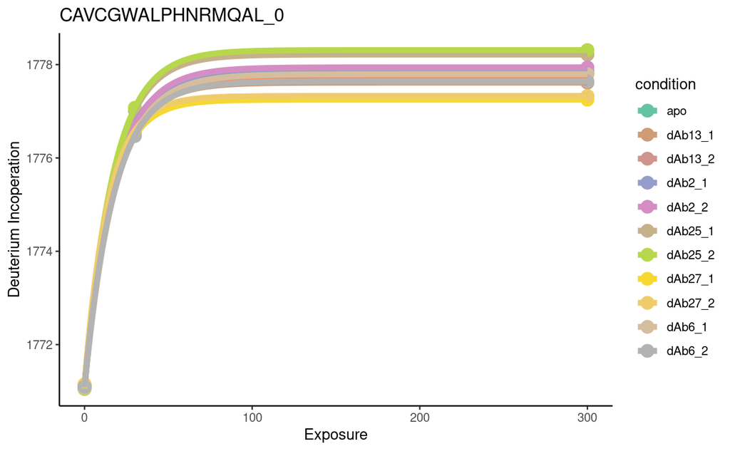

```r
custom_colors <- scale_color_manual(values = colorRampPalette(brewer.pal(8, name = "Set2"))(11))
graphics + custom_colors
```

Remove intercept Deu uptake values

[output not shown]

[output cut: 2516 more lines]

Let’s select column data for the APO state and a bound state with a single domain antibody labelled as `dAb25_1`

```r
data_selection <- hdx_data_nointercept[,c(1:3, 10:12)]
all_peptides <- rownames(data_selection)[[1]] # get all peptides
starting_parameters <- list(a = NULL)
formula = value ~ a * (1 - exp(-0.05*(timepoint)))

results <- analyse_kinetics(data = data_selection,
                            method = "fit",
                            peptide_selection = all_peptides,
                            start = starting_parameters,
                            formula = formula)
```

```
[1] "INFO: Performing fitting of Deuterium uptake kinetics. Method: 'hdxstats::fitUptakeKinetics' "
```

Let’s have look at some of the data analysis output data

```r
results$functional_analysis@results
```

```
DataFrame with 110 rows and 8 columns
                            Fstat.Fstat Fstat.numerator Fstat.denomenator     pvals       fdr ebayes.pvals ebayes.fdr fitcomplete
                                 <list>          <list>            <list> <numeric> <numeric>    <numeric>  <numeric>   <integer>
GPGQECA_0                      0.505943       0.0236133         0.0466718  0.516181  0.652643     0.479007   0.612683           1
CAVCGWALPHNRM_0                0.819962       0.0111598         0.0136102  0.416403  0.558589     0.406959   0.545920           2
CAVCGWALPHNRMQAL_0              3.18841        0.130744         0.0410059  0.148709  0.320744     0.123017   0.300707           3
CAVCGWALPHNRMQALTSCE_0          1.51203        0.598316          0.395703  0.286210  0.499732     0.237829   0.441045           4
AVCGWALPHNRM_0                 0.138914      0.00401256         0.0288852  0.728272  0.801099     0.708845   0.779730           5
...                                 ...             ...               ...       ...       ...          ...        ...         ...
ATERYLHVRPQPLAGEDPPAYQARL_0    0.882916       0.0634907         0.0719102  0.400605  0.557804    0.3563859   0.502596         106
ERYLHVRPQPLAGEDPPAYQ_0         0.841277       0.0671491         0.0798181  0.410930  0.558053    0.3658748   0.509446         107
ERYLHVRPQPLAGEDPPAYQARL_0       2.11026        0.172771          0.081872  0.219967  0.443454    0.1817334   0.386882         108
RYLHVRPQPLAGEDPPAYQARL_0        1.65969        0.120275         0.0724686  0.267115  0.481684    0.2263725   0.436859         109
LQKLTEEVPLGQSIPRRRK_0           4.48223        0.196504         0.0438406  0.101671  0.266280    0.0814249   0.246599         110
```

```r
which(results$functional_analysis@results$ebayes.fdr < 0.05)
```

```
          IQLRESLEPDA_0 RESLEPDAYALFHKKLTEGVL_0         YALFHKKLTEGVL_0       REQLEATCPQCHQTF_0           EATCPQCHQTF_0
                     36                      42                      43                      52                      53
      MYLQENGIDCPKCKF_0     YLQENGIDCPKCKFSYA_0      LQENGIDCPKCKFSYA_0
                     65                      68                      70
```

```r
graphics <- visualise_hdx_data(results, type="kinetics")
```

```
[1] "INFO: I found  110  models in your results data."
```

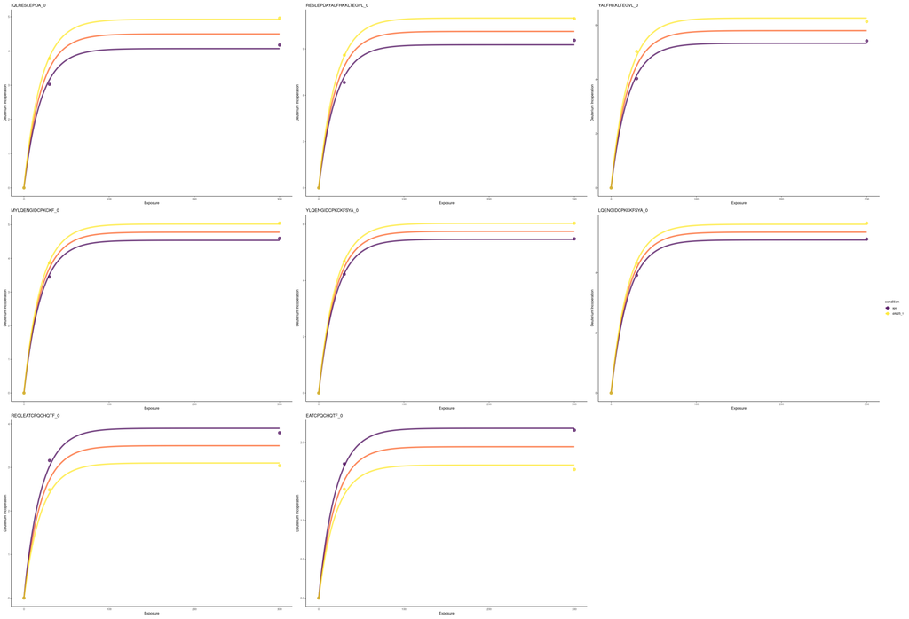

```r
graphics[[36]] +
graphics[[42]] +
graphics[[43]] +
graphics[[65]] +
graphics[[68]] +
graphics[[70]] +
graphics[[52]] +
graphics[[53]] +
plot_layout(guides = 'collect')
```

```r
#graphics <- visualise_hdx_data(results, type="manhatten", reference = NULL)# <<<<--- NEXT
n_cols <- length(as.vector(colnames(data_selection))$incoperation)

message <- paste("INFO: I found",n_cols,"columns in your data selection. I will split your data selection into two and take their difference.")
print(message)
```

```
[1] "INFO: I found 6 columns in your data selection. I will split your data selection into two and take their difference."
```

```r
print(colnames(assay(data_selection)[,1:(n_cols/2)]))
```

```
[1] "X0rep1condapo"   "X30rep1condapo"  "X300rep1condapo"
```

```r
print(colnames(assay(data_selection)[,(1+n_cols/2):n_cols]))
```

```
[1] "X0rep1conddAb25_1"   "X30rep1conddAb25_1"  "X300rep1conddAb25_1"
```

```r
data_diff <- assay(data_selection)[,(1+n_cols/2):n_cols] - assay(data_selection)[,1:(n_cols/2)]

graphics <- list()
for (i in 1:(n_cols/2)){
    graphics[i] <- manhattanplot(params = results$functional_analysis,
                                 sequences = rownames(results$functional_analysis@results),
                                 region = as.data.frame(data_selection@metadata)[, c("Start", "End")],
                                 difference = data_diff[,i],
                                 nrow = 1)
}
message <- paste("INFO: You have ", length(graphics), "Manhattan plots")
print(message)
```

```
[1] "INFO: You have  3 Manhattan plots"
```

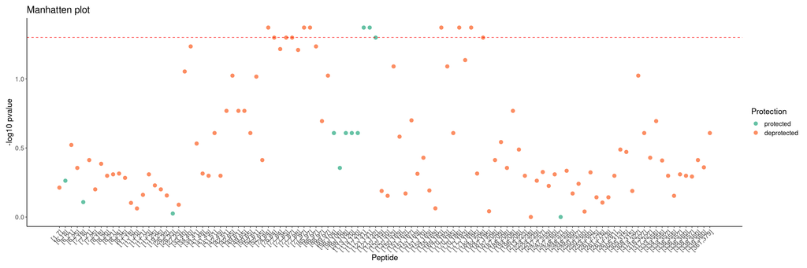

```r
graphics[[2]] + plot_layout(guides = 'collect')
```

```r
graphics_manhatten <- visualise_hdx_data(results, data_selection= data_selection, type="manhatten")
```

```
[1] "INFO: I found 6 columns in your data selection. I will split your data selection into two and take their difference."
[1] "X0rep1condapo"   "X30rep1condapo"  "X300rep1condapo"
[1] "X0rep1conddAb25_1"   "X30rep1conddAb25_1"  "X300rep1conddAb25_1"
[1] "INFO: You have  3 Manhattan plots"
```

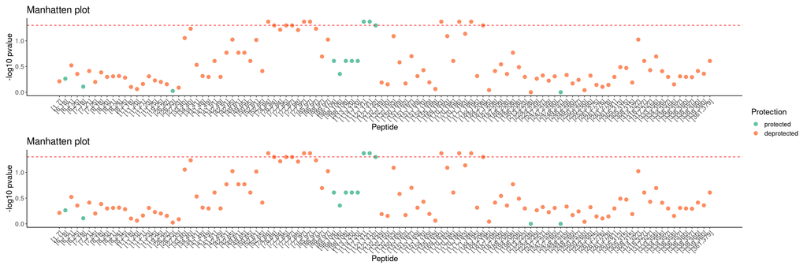

```r
graphics_manhatten[[2]] / graphics_manhatten[[3]] + plot_layout(guides = 'collect')
```

```r
#graphics <- visualise_hdx_data(results, type="epitope", level="peptide", fasta = "my_fasta_path") # Return an EpitopeMap

fpath <- system.file("extdata", "HOIP.txt", package = "hdxstats", mustWork = TRUE)
HOIPfasta <- readAAStringSet(filepath = fpath, "fasta")

scores <- results$functional_analysis@results$ebayes.fdr

out <- plotEpitopeMap(AAString = HOIPfasta[[1]],
                      peptideSeqs = unlist(lapply(strsplit(rownames(assay(hdx_data_nointercept)), split="_"), function(x) head(x,n=1))),
                      numlines = 2,
                      maxmismatch = 2,
                      by = 1, # NOTE: What's the role of this arg that's never called in function?
                      scores = 1 * (-log10(scores[unique(rownames(assay(hdx_data_nointercept)))])  > -log10(0.05)) + 0.0001,
                      name = "significant")
out[[1]]/(out[[2]]) + plot_layout(guides = 'collect') & theme(legend.position = "right")
```

```r
#graphics <- visualise_hdx_data(results, type="epitope", level="peptide", fasta = "my_fasta_path") # Return an EpitopeMap

fasta <- system.file("extdata", "HOIP.txt", package = "hdxstats", mustWork = TRUE)
data_selection <- hdx_data_nointercept

#################################
fasta_data <- readAAStringSet(filepath = fasta, "fasta")
message <- paste("INFO: You input FASTA file contains", length(fasta_data), ". I will take the first entry by default.")
print(message)
```

```
[1] "INFO: You input FASTA file contains 16 . I will take the first entry by default."
```

```r
scores <- results$functional_analysis@results$ebayes.fdr
peptide_charge_names <- rownames(results$functional_analysis@results)
peptide_sequences <- unlist(lapply(strsplit(peptide_charge_names, split="_"), function(x) head(x,n=1)))
# NOTE: What about the charged states? Do they get usually ignored?

graphics <- plotEpitopeMap(AAString = fasta_data[[1]],
                      peptideSeqs = peptide_sequences,
                      numlines = 2,
                      maxmismatch = 2,
                      by = 1, # NOTE: What's the role of this arg that's never called in function?
                      scores = 1 * (-log10(scores[unique(peptide_charge_names)])  > -log10(0.05)) + 0.0001,
                      name = "significant")
graphics[[1]]/(graphics[[2]]) + plot_layout(guides = 'collect') & theme(legend.position = "right")
```

```r
fasta_filepath <- system.file("extdata", "HOIP.txt", package = "hdxstats", mustWork = TRUE)
graphics_epitope <- visualise_hdx_data(results, type="epitope", level="peptide", fasta = fasta_filepath)
```

```
[1] "INFO: You input FASTA file contains 16 . I will take the first entry by default."
```

```
[1] "INFO: You have  2 parts for your Epitope map"
```

```r
graphics_epitope[[1]]/(graphics_epitope[[2]]) +
plot_layout(guides = 'collect') & theme(legend.position = "right")
```

```r
#graphics <- visualise_hdx_data(results, type="epitope", level="residue", fasta = "my_fasta_path") # Return heatmap

scores <- results$functional_analysis@results$ebayes.fdr
out2 <- plotEpitopeMapResidue(AAString = HOIPfasta[[1]],
                              peptideSeqs = unlist(lapply(strsplit(rownames(assay(hdx_data_nointercept)), split="_"), function(x) head(x,n=1))),
                              numlines = 2,
                              maxmismatch = 1,
                              by = 5,
                              scores = scores[unique(rownames(assay(hdx_data_nointercept)))],
                              name = "-log10 p value")
out2[[1]]/out2[[2]]  + plot_layout(guides = 'collect') & theme(legend.position = "right")
```

```r
#graphics <- visualise_hdx_data(results, type="epitope", level="residue", fasta = "my_fasta_path") # Return heatmap

fasta <- system.file("extdata", "HOIP.txt", package = "hdxstats", mustWork = TRUE)
#######################################
fasta_data <- readAAStringSet(filepath = fasta, "fasta")
message <- paste("INFO: You input FASTA file contains", length(fasta_data), ". I will take the first entry by default.")
print(message)
```

```
[1] "INFO: You input FASTA file contains 16 . I will take the first entry by default."
```

```r
peptide_charge_names <- rownames(results$functional_analysis@results)
peptide_sequences <- unlist(lapply(strsplit(peptide_charge_names, split="_"), function(x) head(x,n=1)))

scores <- results$functional_analysis@results$ebayes.fdr

graphics_epitope <- plotEpitopeMapResidue(AAString = fasta_data[[1]],
                                          peptideSeqs = peptide_sequences,
                                          numlines = 2,
                                          maxmismatch = 1,
                                          by = 5,
                                          scores = scores[unique(peptide_charge_names)],
                                          name = "-log10 p value")
graphics_epitope[[1]]/graphics_epitope[[2]]  + plot_layout(guides = 'collect') & theme(legend.position = "right")
```

```r
fasta_filepath <- system.file("extdata", "HOIP.txt", package = "hdxstats", mustWork = TRUE)
graphics_epitope <- visualise_hdx_data(results, type="epitope", level="residue", fasta = fasta_filepath)
```

```
[1] "INFO: You input FASTA file contains 16 . I will take the first entry by default."
[1] "INFO: You have  2 parts for your Epitope map"
```

```r
graphics_epitope[[1]]/(graphics_epitope[[2]]) +
plot_layout(guides = 'collect') & theme(legend.position = "right")
```

Map data onto PDB

Load essential libraries

```r
library("NGLVieweR")
library("tidyverse")
library("RColorBrewer")
library("scales")
library("comprehenr")
library("bio3d")
```

Map protection/deprotection heatmaps onto PDB

```r
source("R/pdb-visualisation.R")
```

```r
scores <- results$functional_analysis@results$ebayes.fdr

peptide_charge_names <- rownames(results$functional_analysis@results)
peptide_sequences <- unlist(lapply(strsplit(peptide_charge_names, split="_"), function(x) head(x,n=1)))

graphics_data <- ComputeAverageMap(AAString = fasta_data[[1]],
                            peptideSeqs = unique(peptide_sequences),
                            numlines = 2, maxmismatch = 1,
                            by = 10, scores = scores[unique(peptide_charge_names)],
                            name = "-log10 p value")
```

```r
dataset <- graphics_data
pdb_filepath <- "vignettes/data/5edv_chainA_clean_renumbered.pdb"
mycolor_parameters <- hdx_to_pdb_colours(dataset, pdb_filepath)
```

```
[1] "Your HDX input dataset has 379 entries"
[1] "And excluding NA data you only have 379 entries"
[1] "However, your input PDB has only 286 residues in total"
[1] "Your scale limits are  0"    "Your scale limits are  1.37"
[1] "Your values will be coloured using Viridis"
```

```r
graphics <- NGLVieweR(pdb_filepath) %>%
  stageParameters(backgroundColor = "white", zoomSpeed = 1) %>%
  addRepresentation("cartoon") %>%
  addRepresentation("cartoon", param = list(color=mycolor_parameters, backgroundColor="white")) #%>%
  #setSpin()
```

```r
graphics
```

```r
pdb_filepath <- "vignettes/data/5edv_chainA_clean_renumbered.pdb"
graphics_pdbview <- visualise_hdx_data(results, type="epitope", level= "residue", pdb= pdb_filepath)

graphics_pdbview %>% setSpin()
```

# TEST CASE 3

Original raw data

```r
#csv_filepath <- "inst/extdata/Project_2_SecA_Cluster_Data.csv"
#data <- read_csv(csv_filepath)
#data$Replicate <- unlist(lapply(strsplit(data$File, split="_"), function(x) tail(x, n=1)))
#write_csv(data, file = "inst/extdata/Project_2_SecA_Cluster_Data_edited.csv")

csv_filepath <- "inst/extdata/Project_2_SecA_Cluster_Data_edited.csv"
```

Had to pre-process its content to add Replicate column

```r
#data <- read_csv(csv_filepath)
#make_parameter_file(data, save = "vignettes/data/Project_2_SecA_Cluster_Data.hdxp")
```

```r
hdx_data <- extract_hdx_data(csv_filepath, parameter_file = "vignettes/data/Project_2_SecA_Cluster_Data.hdxp")
```

```r
pheatmap(t(assay(hdx_data)),
         cluster_rows = FALSE,
         cluster_cols = FALSE,
         color = brewer.pal(n = 9, name = "BuPu"),
         main = "secA heatmap",
         fontsize = 14,
         legend_breaks = c(0, 1, 2, 3, 4, 5, 6, max(assay(hdx_data))),
         legend_labels = c("0", "1", "2", "3", "4", "5", "6", "Incorporation"))
```

```r
# Find out how many unique peptides and charge states exist
length(rownames(assay(hdx_data)))
# Extract all column values for a given peptide and charge state ( all states, all replicates, all timepoints)
peptide_charge <- "VIMDF_1" # "SSQYESAL_1"
Deu_min_global <- apply(assay(hdx_data), 1, function(x) min(x, na.rm = TRUE))[[peptide_charge]]
peptide_charge_data <- as.data.frame(assay(hdx_data))[peptide_charge, ]
peptide_charge_data <- longFormat(peptide_charge_data)
peptide_charge_data$condition <- as.factor(str_match(peptide_charge_data$colname, "cond\\s*(.*)")[, 2]) # Modify this for data analysis functions since they expect a numeric for replicates
peptide_charge_conditions <- unique(peptide_charge_data$condition)
# For a fixed confition
state <- "SecAYEG_AMPPNP"
ldf <- peptide_charge_data %>% subset(condition == state)
ldf$timepoint <- as.numeric(str_match(ldf$colname, "X\\s*(.*?)\\s*rep")[, 2])
ldf$replicates <- as.factor(str_match(ldf$colname, "rep\\s*(.*)\\s*cond")[, 2])
# Identify if number of replicates for 0 timepoint match for subsequent timepoints and report if not the case
#sum(ldf$timepoint == 0)
#length(unique(ldf$timepoint))
ldf$replicates <- unlist(lapply(strsplit(as.vector(as.factor(str_match(ldf$colname, "rep\\s*(.*)\\s*cond")[, 2])), split="_"), function(x) tail(x, n=1)))

# Subtract Deu uptake value at 0 timepoint
replicate_number <- 3
single_replicate_data <- ldf %>% subset(replicates == replicate_number)
x <- single_replicate_data %>% subset(timepoint == 0) # NOTE: Sometimes there will be more than one 0 timepoint
message <- paste("INFO: You have", length(x$value),"Deu uptake values for the zero timepoint.")
print(message)

if (all(is.na(x$value))){
    message <- "INFO: All Deu uptake values for the zero timepoint are NA. I will take the minimum across all conditions."
    print(message)
    single_replicate_data$value <- single_replicate_data$value - Deu_min_global
    print(single_replicate_data)
}else{
    message <- "INFO: At least one Deu uptake values for the zero timepoint is NA. I will take the minimum of all zero timepoints"
    print(message)
    Deu_min <- min(x$value, na.rm = TRUE)
    print("BEFORE")
    print(single_replicate_data)
    single_replicate_data$value <- single_replicate_data$value - Deu_min
    print("AFTER")
    print(single_replicate_data)
}
```

```r
message <-paste("INFO: You have", length(rownames(assay(hdx_data))), "peptide-charge paired values")
print(message)
ldf_new <- rbind()
for (peptide_charge in rownames(assay(hdx_data))){
  peptide_charge_data <- as.data.frame(assay(hdx_data))[peptide_charge, ]
  peptide_charge_data <- longFormat(peptide_charge_data)
  peptide_charge_data$condition <- as.factor(str_match(peptide_charge_data$colname, "cond\\s*(.*)")[, 2])

  Deu_min_global <- apply(assay(hdx_data), 1, function(x) min(x, na.rm = TRUE))[[peptide_charge]]

  peptide_charge_conditions <- unique(peptide_charge_data$condition)
  message <- paste("INFO: For ", peptide_charge, ", you have", length(peptide_charge_conditions), "conditions")
  print(message)

  #ldf_new <- rbind()
  for (state in peptide_charge_conditions){
    ldf <- peptide_charge_data %>% subset(condition == state)
    ldf$timepoint <- as.numeric(str_match(ldf$colname, "X\\s*(.*?)\\s*rep")[, 2])
    ldf$replicates <- as.factor(str_match(ldf$colname, "rep\\s*(.*)\\s*cond")[, 2])

    ldf$replicates <- unlist(lapply(strsplit(as.vector(as.factor(str_match(ldf$colname, "rep\\s*(.*)\\s*cond")[, 2])), split="_"), function(x) tail(x, n=1)))
    # Subtract Deu uptake value at 0 timepoint
    message <- paste("INFO: You have", length(unique(ldf$replicates)), "replicates, for", state)
    print(message)

    for (n_replicate in unique(ldf$replicates)){
      single_replicate_data <- ldf %>% subset(replicates == n_replicate)
      x <- single_replicate_data %>% subset(timepoint == 0)

      if (all(is.na(x$value))){
        message <- "INFO: All Deu uptake values for the zero timepoint are NA. I will take the minimum across all conditions."
        print(message)
        single_replicate_data$value <- single_replicate_data$value - Deu_min_global
        #print(single_replicate_data)
        ldf_new <- rbind(ldf_new, single_replicate_data)
        }else{
            message <- "INFO: At least one Deu uptake values for the zero timepoint is NA. I will take the minimum of all zero timepoints"
            print(message)
            Deu_min <- min(x$value, na.rm = TRUE)
            single_replicate_data$value <- single_replicate_data$value - Deu_min
            #print(single_replicate_data)
            ldf_new <- rbind(ldf_new, single_replicate_data)
        }
    }
  }
}

x <- DataFrame(ldf_new)
x_wide <- pivot_wider(data.frame(x), values_from = value, id_cols = rowname, names_from = colname)
x_wide_df <- DataFrame(x_wide)
x_wide_df$rownames <- x_wide$rowname
qFeat <- readQFeatures(data.frame(x_wide_df), ecol = 1:ncol(assay(hdx_data)), name = names(hdx_data), fnames = "rownames")
```

```r
#graphics <- visualise_hdx_data(results, type="kinetics") # READY
#graphics <- visualise_hdx_data(results, type="forest") # READY

# NOTE: This only works to compare ONLY TWO distinct conditions, for the same timepoint, for all peptide fragments
# This needs to define a BASELINE state/condition and an ALTERNATE sate/condition
# NOTE: Data must be normalised by intercept
#graphics <- visualise_hdx_data(results, type="manhatten", reference = NULL)# <<<<--- NEXT
#graphics <- visualise_hdx_data(results, type="epitope", level="peptide", fasta = "my_fasta_path") # Return an EpitopeMap # <<<<--- NEXT
#graphics <- visualise_hdx_data(results, type="epitope", level="residue", fasta = "my_fasta_path") # Return heatmap # <<<<--- NEXT
#graphics <- visualise_hdx_data(results, type="epitope", level="residue", pdb="my_pdb_path") # Return heatmap projected onto PDB # <<<<--- NEXT

graphics <- visualise_hdx_data(results, type="protection", level="peptide") # Return heatmap for peptide residue-number ranges
graphics <- visualise_hdx_data(results, type="protection", level="residue", fasta = "my_fasta_path") # Return heatmap
graphics <- visualise_hdx_data(results, type="protection", level="residue", pdb="my_pdb_path") # Return heatmap projected onto PDB

# GUI: Make GUI by assembling these building blocks
```